# TestRiskScores

Agaz Wani

11/12/2021

### Note: Please generate the Rmarkdown (and to maintain size an font of plot) and share with me. You can run the file chunk wise and then generate Rmarkdown as final file. Here we’ll use without nonCpGs and XY probes dataset.

### Update: 6/26/2023

### Replace linear with logit model, use point-biserial correlation and update the plots for publication

### This notebook combines all three models

#### 1. Exposure and methylation risk score (eMRS)

#### 2. Methylation only risk score (MoRS)

#### 3. Methylation only risk score with adjusted exposures (MoRSAE)

### Clean workspace

```r
rm(list = ls())
gc()
```

```
##          used (Mb) gc trigger (Mb) max used (Mb)
## Ncells 520384 27.8    1156617 61.8   660388 35.3
## Vcells 949281  7.3    8388608 64.0  1770552 13.6
```

## Code to test association between risk scores and PTSD

### Load the data that was saved in previous steps, i.e covariate adjusted and scaled. I.e. the output from files `Covariate_Adj_RiskScores_1.R` for eMRS and `Covariate_Adj_RiskScores_without_exp_vars_1.R` for MoRS and MORSAE.

```r
emrs_mors <- "../data/Covariate adjusted and scaled data.xlsx" # Output from "downstream_analysis_v5.qmd"

morsae <- "../data/Covariate adjusted and scaled data wd adjusted exp vars.xlsx" # output from downstream_analysis_adj_for_Exp_Vars_v5.qmd


# function to read all sheets
read_allsheets <- function(path){
  sheet_nms <- getSheetNames(path)
  sheets <- lapply(sheet_nms, read.xlsx, xlsxFile = path)
  names(sheets) <- sheet_nms
  return(sheets)
}

# eMRS
emrs_mors_df <- read_allsheets(path = emrs_mors)

# MoRS and MoRSAE
morsae_dfs <- read_allsheets(path = morsae)


# combine all three dfs together
adj_df <- c(list("With Exposure Variables" = emrs_mors_df$`Without NonCpGXY Probes`,
                 "Without Exposures in model" = emrs_mors_df$`Without NonCpGXY ProbesWoExpVar`,
                 "With Adjusted Exposures" = morsae_dfs$`Without NonCpGXY Probes`))
```

### Now setup the name of cohort

```r
cohort <- "VA Boston:" # change the name here
```

### Now convert some columns into factor. We decide to drop lifetime PTSD

```r
ptsd_cols <- "CurrentPTSD"
adj_df <- lapply(adj_df, function(x){
  x[ptsd_cols] <- lapply(x[ptsd_cols], factor)
  x
})
```

### Get correlation plot for important phenotypes. Assign new names to make it short and readeable. Keep Trauma exposures to find correlation with risk scores

```r
cor_cols_emrs <- c("TraumaNumber", "ChildhoodMaltreatment",
                "risk_score", ptsd_cols)

cor_cols_mors_morsae <- c("TraumaNumber", "ChildhoodMaltreatment",
                "meth_only_risk_score", ptsd_cols)

# only current ptsd
new_names_wd_exp <- c("Trauma", "Chd Trauma", "eMRS", "PTSD")

new_names_wo_exp <- c("Trauma", "Chd Trauma", "MoRS", "PTSD")

new_names_wd_adj_exp <- c("Trauma", "Chd Trauma", "MoRSAE", "PTSD")
```

### Function to get correlation and adjusted pvalue. Input is data frame, columns we want to get correlation for and new names to assign to columns.

```r
get_correlation <- function(df, cols, new_names){


  # As we have many dfs, lets check which cols are present
  # and use those cols
  cols_present <- which(cols %in% colnames(df))
  cols <- cols[cols_present]
  new_names <- new_names[cols_present]

  # get the cols from df and correlation
  df <- df %>% select(cols)
  indx <- sapply(df, is.factor)
  df[indx] <- lapply(df[indx], function(x) as.numeric(as.character(x)))
  colnames(df) <- new_names
  cor_df <- cor(df)
  p = cor.mtest(df, conf.level = 0.95)


  # Point-biserial correlation between contineous and binary variables
  res <- lapply(new_names, function(y){ # loop over cols
    xcol <- 'PTSD'
    ycol <- y
    x1 <- df[[xcol]]
    y <- df[[ycol]]
    bc <- cor.test(y, x1)
    res <- list(bc$estimate, bc$p.value, bc$statistic)
    names(res) <- c('cor', 'p.val', 't')
    res <- do.call(cbind, res)
    rownames(res) <- ycol
    res
    })
  res <- do.call(rbind, res)

  # replace cor and pval with point biserial
  cor_df[, "PTSD"] <- res[, "cor"]
  p$p[, "PTSD"] <- res[, 'p.val']

  # adjusted pvalues
  p_adj <- matrix(p.adjust(as.vector(as.matrix(p$p)),
                           method='fdr'),
                  ncol=ncol(cor_df))
  rownames(p_adj) <- new_names
  colnames(p_adj) <- new_names

  # point biserial padjusted between contineous and PTSD
  p_adj_bs <- p.adjust(res[, 'p.val'], method = 'fdr')
  p_adj[, "PTSD"] <- p_adj_bs
  df_ls <- list(cor_df, p_adj, p$p)
  names(df_ls) <- c("cor", "padj", "pval")
  return(df_ls)
}

# color palette
colrs <- colorRampPalette(c("#0072B5FF", '#7F0000',
                            '#FF7F00', 'orange',
                            'cyan', '#007FFF', 'blue', '#00007F',
                            "#BC3C29FF"))
```

### Now call the function to get correlation

```r
cor_adj_df <- lapply(seq_along(adj_df), function(i){ # loop over each df
  if(names(adj_df)[i] == "With Exposure Variables"){ # eMRS
    new_names <- new_names_wd_exp
    cor_cols <- cor_cols_emrs

  }else if(names(adj_df)[i] == "Without Exposures in model"){ # MoRS
    new_names <- new_names_wo_exp
    cor_cols <- cor_cols_mors_morsae

  }else{
    new_names <- new_names_wd_adj_exp # MoRSAE
    cor_cols <- cor_cols_mors_morsae
  }

  get_correlation(df = adj_df[[i]], cols = cor_cols,
                  new_names = new_names)
})
names(cor_adj_df) <- names(adj_df)
print(cor_adj_df)
```

```
## $`With Exposure Variables`
## $`With Exposure Variables`$cor
##               Trauma Chd Trauma      eMRS      PTSD
## Trauma     1.0000000  0.3525294 0.4051895 0.2979461
## Chd Trauma 0.3525294  1.0000000 0.5710585 0.4572552
## eMRS       0.4051895  0.5710585 1.0000000 0.7210605
## PTSD       0.2979461  0.4572552 0.7210605 1.0000000
##
## $`With Exposure Variables`$padj
##                  Trauma   Chd Trauma         eMRS         PTSD
## Trauma     0.000000e+00 2.353455e-10 1.959309e-13 1.035039e-07
## Chd Trauma 2.353455e-10 0.000000e+00 1.150655e-27 3.837384e-17
## eMRS       1.959309e-13 1.150655e-27 0.000000e+00 3.165135e-50
## PTSD       1.035039e-07 4.604861e-17 4.220180e-50 0.000000e+00
##
## $`With Exposure Variables`$pval
##                  Trauma   Chd Trauma         eMRS         PTSD
## Trauma     0.000000e+00 2.059273e-10 1.469482e-13 1.035039e-07
## Chd Trauma 2.059273e-10 0.000000e+00 5.753273e-28 2.878038e-17
## eMRS       1.469482e-13 5.753273e-28 0.000000e+00 1.582568e-50
## PTSD       1.035039e-07 2.878038e-17 1.582568e-50 0.000000e+00
##
##
## $`Without Exposures in model`
## $`Without Exposures in model`$cor
##               Trauma Chd Trauma      MoRS      PTSD
## Trauma     1.0000000  0.3525294 0.1648523 0.2979461
## Chd Trauma 0.3525294  1.0000000 0.1695991 0.4572552
## MoRS       0.1648523  0.1695991 1.0000000 0.6224911
## PTSD       0.2979461  0.4572552 0.6224911 1.0000000
##
## $`Without Exposures in model`$padj
##                  Trauma   Chd Trauma         MoRS         PTSD
## Trauma     0.000000e+00 3.294836e-10 3.773438e-03 1.035039e-07
## Chd Trauma 3.294836e-10 0.000000e+00 3.282251e-03 3.837384e-17
## MoRS       3.773438e-03 3.282251e-03 0.000000e+00 4.992552e-34
## PTSD       1.380052e-07 5.756076e-17 6.656736e-34 0.000000e+00
##
## $`Without Exposures in model`$pval
##                  Trauma   Chd Trauma         MoRS         PTSD
```

[output cut: 12 more lines]

```
## PTSD        0.2979461  0.4572552  0.4924290 1.0000000
##
## $`With Adjusted Exposures`$padj
##                  Trauma   Chd Trauma       MoRSAE         PTSD
## Trauma     0.000000e+00 3.294836e-10 2.144639e-02 1.035039e-07
## Chd Trauma 3.294836e-10 0.000000e+00 3.370088e-02 3.837384e-17
## MoRSAE     2.144639e-02 3.370088e-02 0.000000e+00 7.427734e-20
## PTSD       1.380052e-07 5.756076e-17 9.903645e-20 0.000000e+00
##
## $`With Adjusted Exposures`$pval
##                  Trauma   Chd Trauma       MoRSAE         PTSD
## Trauma     0.000000e+00 2.059273e-10 1.876559e-02 1.035039e-07
## Chd Trauma 2.059273e-10 0.000000e+00 3.370088e-02 2.878038e-17
## MoRSAE     1.876559e-02 3.370088e-02 0.000000e+00 3.713867e-20
## PTSD       1.035039e-07 2.878038e-17 3.713867e-20 0.000000e+00
```

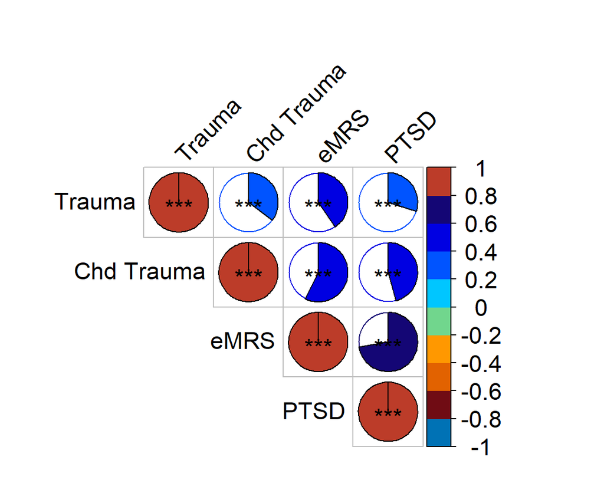

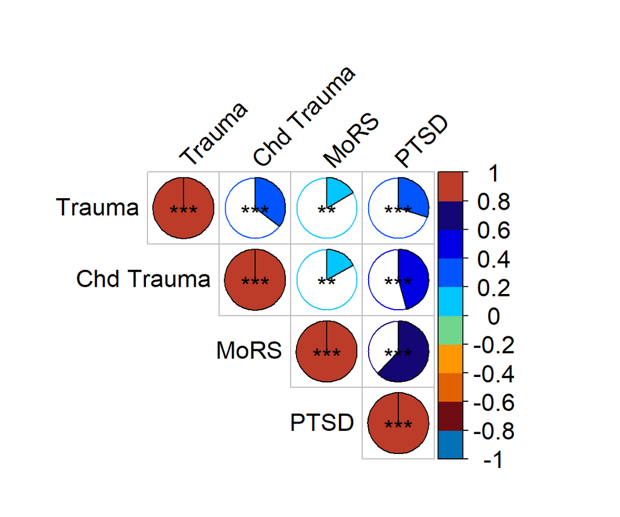

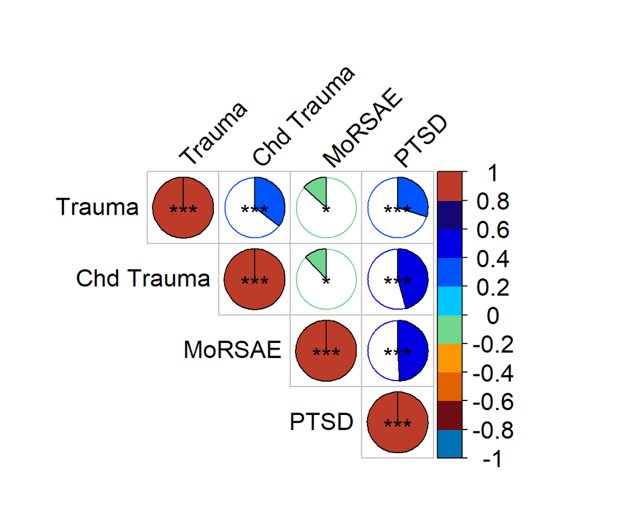

```r
# Function to get correlation between different variables
correlation_plot <- function(cor_df, title=NULL){
  corrplot(cor_df$cor,
  p.mat = cor_df$padj,
  diag = TRUE, method = "pie",
  type = "upper",  number.cex = 0.8,
  tl.col = "black", tl.srt = 45,
  tl.cex = 1.4, cl.cex = 1.4,
  sig.level = c(0.001, 0.01, 0.05),
  pch.cex = 1.4,insig = 'label_sig',
  cl.ratio = 0.4,
  mar = c(0,0,1,0),
  col = colrs(10),
  title = title)
  recordPlot()
}


# Helper function to get correlation between variable.
# It will run the above correlation function for all the data
correlation_plot_helper <- function(cor_df){
  if(is.list(cor_df)){ # loop over study
    n <- names(cor_df)
    p <- lapply(seq_along(cor_df), function(i) {
      p <- correlation_plot(cor_df[[i]])
      })
    names(p) <- n
    p
    }else{
    p <- correlation_plot(cor_df)
    }
}


p_adj <- correlation_plot_helper(cor_df = cor_adj_df)
```

## Correlation plot grid

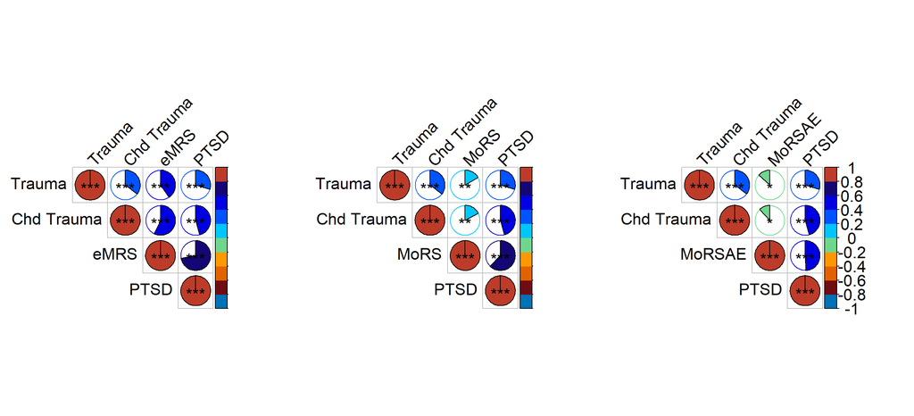

```r
plot_grid(p_adj$`With Exposure Variables`,
          p_adj$`Without Exposures in model`,
          p_adj$`With Adjusted Exposures`,
          rel_widths = c(1,1,1), nrow = 1)
```

## linear model plot setting and function

```r
th <-   theme(plot.title = element_text(size = 20, hjust = 0.5),
              axis.title = element_text(size =18),
              axis.text = element_text(size = 16),
              legend.title = element_text( size = 18),
              legend.text = element_text(size = 16))
```

# Logistic regression model, risk scores predicting PTSD

```r
logit_helper <- function(df, f){

  if(inherits(df, "list")){
    n <- names(df)
    logit <- lapply(seq_along(df), function(i){
      print("=====================================================")
      if (n[i] == "With Exposure Variables"){ # if eMRS
        f <- f_ptsd_emrs
        }else{f <- f_ptsd_meth}     # MoRS or MoRSAE

      analy <- paste(c(
        paste(c("Data frame", deparse(substitute(df))), collapse = ':'),
        paste(c("Formula", f), collapse = ':')), collapse = ', ')
      print(analy)

      # logit
      x <- glm(f, data = df[[i]], family = "binomial")
      print(n[i])
      print(summary(x))


      # using rms package to get pseud rsquared
      message("Pseudo RSquared ...................")
      mod1b <- lrm(f, data = df[[i]])
      print(mod1b)

      x
    })
  }
}


# formula for logistic regression model
f_ptsd_emrs <- as.formula(paste('CurrentPTSD~', 'risk_score'))
f_ptsd_meth <- as.formula(paste('CurrentPTSD~', 'meth_only_risk_score'))

# sink("../Data/Linear model PTSD summary with and wo exposure variables.txt") # path to output file


# Methylation only risk scores Vs. current PTSD
logit_adj_meth <- logit_helper(df = adj_df, f = f_ptsd_meth)
```

```
## [1] "====================================================="
## [1] "Data frame:df, Formula:CurrentPTSD ~ risk_score"
## [1] "With Exposure Variables"
##
## Call:
## glm(formula = f, family = "binomial", data = df[[i]])
##
## Coefficients:
##             Estimate Std. Error z value Pr(>|z|)
## (Intercept)  -3.7873     0.4332  -8.743  < 2e-16 ***
## risk_score    2.6497     0.3481   7.612  2.7e-14 ***
## ---
## Signif. codes:  0 '***' 0.001 '**' 0.01 '*' 0.05 '.' 0.1 ' ' 1
##
## (Dispersion parameter for binomial family taken to be 1)
##
##     Null deviance: 350.13  on 306  degrees of freedom
## Residual deviance: 150.58  on 305  degrees of freedom
## AIC: 154.58
##
## Number of Fisher Scoring iterations: 7
```

```
## Pseudo RSquared ...................
```

```
## Logistic Regression Model
##
## lrm(formula = f, data = df[[i]])
##
##                        Model Likelihood    Discrimination    Rank Discrim.
##                              Ratio Test           Indexes          Indexes
## Obs           307    LR chi2     199.55    R2       0.703    C       0.938
##  0            228    d.f.             1    R2(1,307)0.476    Dxy     0.877
##  1             79    Pr(> chi2) <0.0001    R2(1,176)0.676    gamma   0.877
## max |deriv| 3e-07                          Brier    0.072    tau-a   0.336
##
##            Coef    S.E.   Wald Z Pr(>|Z|)
## Intercept  -3.7873 0.4332 -8.74  <0.0001
## risk_score  2.6497 0.3481  7.61  <0.0001
##
## [1] "====================================================="
## [1] "Data frame:df, Formula:CurrentPTSD ~ meth_only_risk_score"
## [1] "Without Exposures in model"
##
## Call:
## glm(formula = f, family = "binomial", data = df[[i]])
##
## Coefficients:
##                      Estimate Std. Error z value Pr(>|z|)
## (Intercept)           -3.1044     0.3400  -9.132  < 2e-16 ***
## meth_only_risk_score   2.0023     0.2451   8.171 3.07e-16 ***
## ---
## Signif. codes:  0 '***' 0.001 '**' 0.01 '*' 0.05 '.' 0.1 ' ' 1
##
## (Dispersion parameter for binomial family taken to be 1)
##
##     Null deviance: 350.13  on 306  degrees of freedom
## Residual deviance: 207.70  on 305  degrees of freedom
## AIC: 211.7
##
## Number of Fisher Scoring iterations: 6
```

```
## Pseudo RSquared ...................
```

```
## Logistic Regression Model
##
## lrm(formula = f, data = df[[i]])
##
##                        Model Likelihood    Discrimination    Rank Discrim.
##                              Ratio Test           Indexes          Indexes
## Obs           307    LR chi2     142.43    R2       0.546    C       0.887
##  0            228    d.f.             1    R2(1,307)0.369    Dxy     0.774
##  1             79    Pr(> chi2) <0.0001    R2(1,176)0.552    gamma   0.774
## max |deriv| 1e-12                          Brier    0.101    tau-a   0.297
##
##                      Coef    S.E.   Wald Z Pr(>|Z|)
## Intercept            -3.1044 0.3400 -9.13  <0.0001
## meth_only_risk_score  2.0023 0.2451  8.17  <0.0001
##
## [1] "====================================================="
## [1] "Data frame:df, Formula:CurrentPTSD ~ meth_only_risk_score"
## [1] "With Adjusted Exposures"
##
## Call:
## glm(formula = f, family = "binomial", data = df[[i]])
##
## Coefficients:
##                      Estimate Std. Error z value Pr(>|z|)
## (Intercept)           -3.2431     0.3578  -9.064  < 2e-16 ***
## meth_only_risk_score   1.2021     0.1583   7.595 3.07e-14 ***
## ---
## Signif. codes:  0 '***' 0.001 '**' 0.01 '*' 0.05 '.' 0.1 ' ' 1
##
## (Dispersion parameter for binomial family taken to be 1)
##
##     Null deviance: 350.13  on 306  degrees of freedom
## Residual deviance: 262.69  on 305  degrees of freedom
## AIC: 266.69
##
## Number of Fisher Scoring iterations: 5
```

```
## Pseudo RSquared ...................
```

```
## Logistic Regression Model
##
## lrm(formula = f, data = df[[i]])
##
##                        Model Likelihood    Discrimination    Rank Discrim.
##                              Ratio Test           Indexes          Indexes
## Obs           307    LR chi2      87.44    R2       0.364    C       0.808
##  0            228    d.f.             1    R2(1,307)0.245    Dxy     0.616
##  1             79    Pr(> chi2) <0.0001    R2(1,176)0.388    gamma   0.616
## max |deriv| 2e-09                          Brier    0.125    tau-a   0.236
##
##                      Coef    S.E.   Wald Z Pr(>|Z|)
## Intercept            -3.2431 0.3578 -9.06  <0.0001
## meth_only_risk_score  1.2021 0.1583  7.60  <0.0001
```

```r
ci <- lapply(logit_adj_meth, function(x) confint(x))
names(ci) <- names(adj_df)
print(ci)
```

```
## $`With Exposure Variables`
##                 2.5 %    97.5 %
## (Intercept) -4.725980 -3.015576
## risk_score   2.035793  3.409568
##
## $`Without Exposures in model`
##                          2.5 %    97.5 %
## (Intercept)          -3.826387 -2.487389
## meth_only_risk_score  1.557884  2.523317
##
## $`With Adjusted Exposures`
##                           2.5 %    97.5 %
## (Intercept)          -3.9910901 -2.583925
## meth_only_risk_score  0.9077608  1.530218
```

```r
# sink()
```

### Density plot function

```r
make_densityplot <- function(df, x, y, xlab, ylab, fig_legend = TRUE,
                             title = '', legend = '', facet = FALSE){

  p <- ggplot(data=df, aes_string(x=x, group=y, fill=y)) +
    geom_density(adjust=1.5, alpha=.8) +
    theme_classic()

  if(facet != FALSE){
    print('Adding facet')
    p <- p + facet_wrap(as.formula(paste("~", facet)))+
      theme(strip.text.x = element_text(size = 16))
  }


  if(fig_legend){
    p <- p + scale_fill_manual(legend,
                      values  = c("#0072B5FF", "#BC3C29FF"))
  }else{
    p <- p + scale_fill_manual(legend,
                      values  = c("#0072B5FF", "#BC3C29FF")) +
      theme(legend.position = 'none')
  }

  p <- p + ggtitle(title) +
    xlab(xlab) +
    ylab(ylab)+ th
}
```

## Box plot function

```r
make_boxplot <- function(df, x, y, xlab, ylab,
                         test_pval, y_pos, title = ""){
  p <- df %>%
    ggplot(aes_string(x = x, y = y, fill = x)) +
    geom_boxplot(lwd = 1) +
    scale_fill_manual(values = c("#0072B5FF", "#BC3C29FF")) +
    geom_jitter(size=1.7, alpha=0.9) +
    theme_classic()+
    theme(legend.position="none") + th +

    ggtitle(title) +
    xlab(xlab) +
    ylab(ylab)

  # add significance
  p + geom_signif(
    annotation = formatC(test_pval, digits = 2),
    y_position = y_pos , xmin = 1, xmax = 2, size = 1,
    textsize = 5, tip_length = c(0.15, 0.02))
}
```

### Plot for publication. We will plot data without nonCpGs and XY probes.

```r
# Density plots ---------------

p1_emrs <- make_densityplot(df = adj_df$`With Exposure Variables`,
                       x = 'risk_score',
                       y = 'CurrentPTSD',
                       xlab = 'eMRS',
                       ylab = "Density",
                       fig_legend = FALSE)
p1_mors <- make_densityplot(df = adj_df$`Without Exposures in model`,
                       x = 'meth_only_risk_score',
                       y = 'CurrentPTSD',
                       xlab = 'MoRS',
                       ylab = "",
                       fig_legend = FALSE)


p1_morsae <-  make_densityplot(df = adj_df$`With Adjusted Exposures`,
                       x = 'meth_only_risk_score',
                       y = 'CurrentPTSD',
                       xlab = 'MoRSAE',
                       ylab = "",
                       legend = "Current\n PTSD")


# Box plot ----------------------


wcox_emrs <- wilcox.test(risk_score ~ CurrentPTSD,
                        data = adj_df$`With Exposure Variables`)
wcox_emrs
```

```
##
##  Wilcoxon rank sum test with continuity correction
##
## data:  risk_score by CurrentPTSD
## W = 1107, p-value < 2.2e-16
## alternative hypothesis: true location shift is not equal to 0
```

```r
wcox_emrs$p.value
```

```
## [1] 3.393875e-31
```

```r
# MoRS
wcox_mors <- wilcox.test(meth_only_risk_score ~ CurrentPTSD,
                        data = adj_df$`Without Exposures in model`)
wcox_mors
```

```
##
##  Wilcoxon rank sum test with continuity correction
##
## data:  meth_only_risk_score by CurrentPTSD
## W = 2033, p-value < 2.2e-16
## alternative hypothesis: true location shift is not equal to 0
```

```r
wcox_mors$p.value
```

```
## [1] 1.127294e-24
```

```r
# MoRSAE
wcox_morsae <- wilcox.test(meth_only_risk_score ~ CurrentPTSD,
                        data = adj_df$`With Adjusted Exposures`)
wcox_morsae
```

```
##
##  Wilcoxon rank sum test with continuity correction
##
## data:  meth_only_risk_score by CurrentPTSD
## W = 3460, p-value = 3.464e-16
## alternative hypothesis: true location shift is not equal to 0
```

```r
wcox_morsae$p.value
```

```
## [1] 3.464215e-16
```

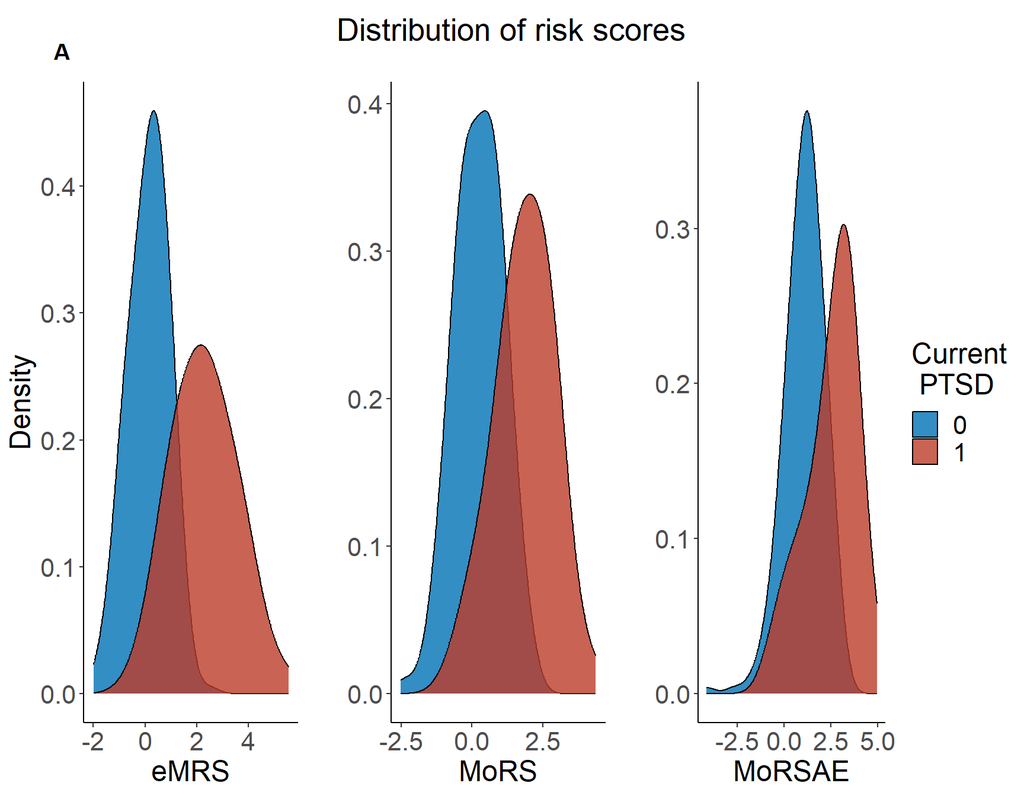

```r
p2_emrs <- make_boxplot(df = adj_df$`With Exposure Variables`,
                        x = 'CurrentPTSD',
                        y = 'risk_score',
                        xlab = '',
                        ylab = 'eMRS',
                        test_pval = wcox_emrs$p.value,
                        y_pos = 4.7, #location to show significance, please change if needed
                        title = "")


p2_mors <- make_boxplot(df = adj_df$`Without Exposures in model`,
                        x = 'CurrentPTSD',
                        y = 'meth_only_risk_score',
                        xlab = '',
                        ylab = 'MoRS',
                        test_pval = wcox_mors$p.value,
                        y_pos = 3.8, #location to show significance, please change if needed
                        title = "")


p2_morsae <- make_boxplot(df = adj_df$`With Adjusted Exposures`,
                        x = 'CurrentPTSD',
                        y = 'meth_only_risk_score',
                        xlab = '',
                        ylab = 'MoRSAE',
                        test_pval = wcox_morsae$p.value,
                        y_pos = 4.6, #location to show significance, please change if needed
                        title = "")


# arrange den plots
p_den <- cowplot::plot_grid(p1_emrs, p1_mors, p1_morsae,
                            nrow = 1, labels = c('A'),
                            label_x = .15,
                            rel_widths = c(1.5, 1.5, 2))

# add title to den plots
title_den.grob <- textGrob("Distribution of risk scores",

                   gp=gpar(fontsize=20), vjust = 1)

p_den <- grid.arrange(arrangeGrob(p_den, top = title_den.grob))
```

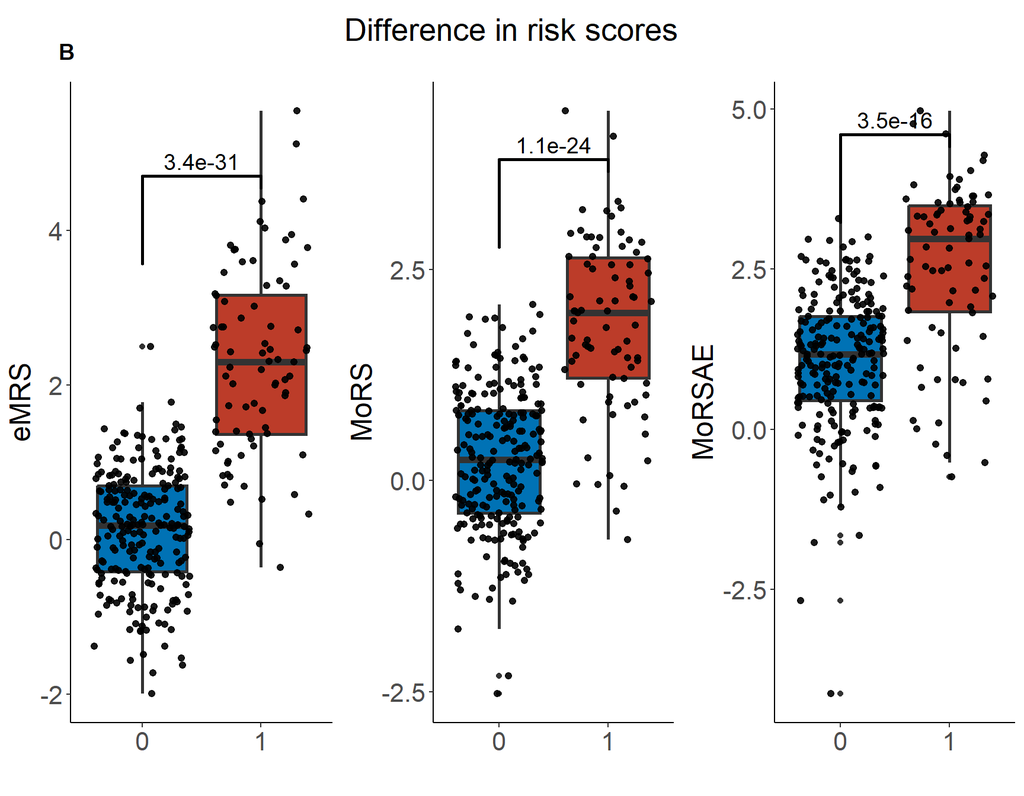

```r
# arrange box plots
p_box <- cowplot::plot_grid(p2_emrs, p2_mors, p2_morsae,
                            nrow = 1, labels = c('B'),
                            label_x = .15)

# add title to box plots
title.grob <- textGrob("Difference in risk scores",
                   gp=gpar(fontsize=20), vjust = 1)

p_box <- grid.arrange(arrangeGrob(p_box, top = title.grob))
```

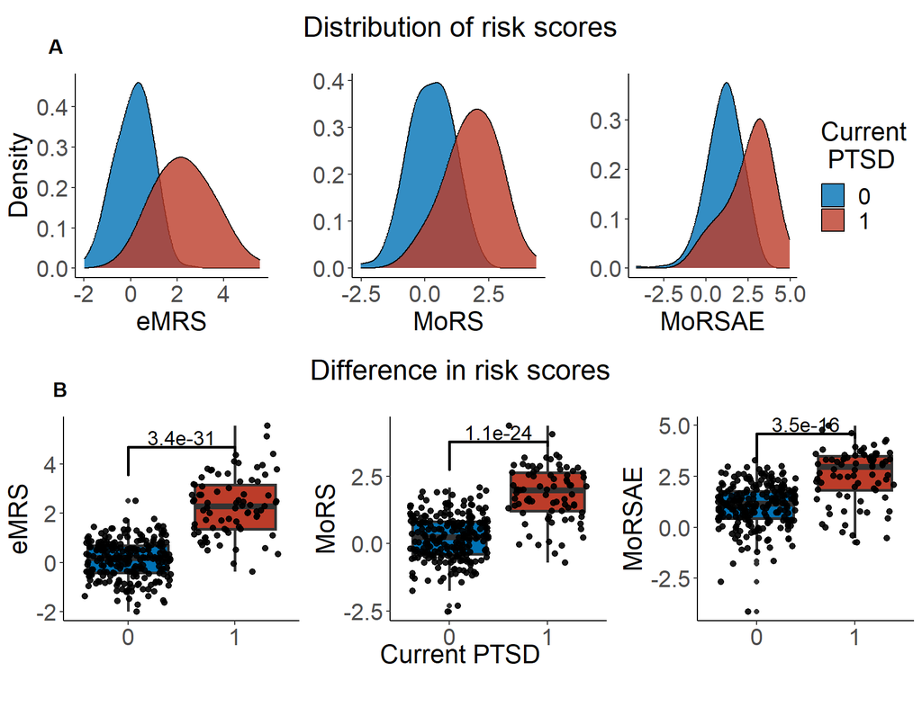

```r
# add x label to box plots
x.grob <- textGrob("Current PTSD",
                   gp=gpar(fontsize=18), vjust = -2)

# arrange plots in grid
p_comb <- cowplot::plot_grid(p_den,p_box, nrow = 2)

grid.arrange(arrangeGrob(p_comb, bottom = x.grob))
```